# Mid-term project instructions

Author

Anish Bhattarai & Aleena Rayamajhi

Paste here the URL of the GitHub project (after going through the instruction steps)

[Anish Aleena midterm project github link](https://github.com/Leoanish/2024dsa_midterm_AnishAleena/)

# 1 Instructions

This file contains both the **instructions** for the mid-term project and placeholders for your code. You are required to use this file to produce code, output, and answers to the questions below.

Besides simply creating output, make sure to interpret the output. You will need to create tables and/or plots to arrive at the answers, and then comment on what you found below it.

To get you setup, you will need to:

- Student #1: create a repository on your GitHub account. You can call this repository “2024dsa_midproject_groupX”, **where X is the number of your group**. Make it public, add a README, add a .gitignore for R.
- Student #1: follow the steps we did in class to start a new RStudio project with version control.
- Student #1: in your computer, create the sub-folders code, data, output, and move your data set into the `data` folder. Also, student 1 moves this current script into the `code` folder. Do a git stage, commit, push.
- Student #1: on GitHub, go the repository settings and invite your partner to be a collaborator in the repository. That will give them push permission.
- Now, both students should clone this repository on their computers like we did in class. Make sure this step works well and that you can pull and push from GitHub.
- Student 2, after cloning, does a git pull to get all these updates on their computer.
- Student 1 and 2 work together to update the README file. README files should explain what the repository is about, the goals of that project, who is working in it, and any other important details you may find.

# 2 Introduction

Describe here the introduction of your problem. Consider this as a shortened version of your paper, where you will briefly discuss in 3-4 paragraphs what is the issue/gap in literature, and how the data you collected will help answer this gap.

**Nitrogen (N) plays a critical role as a mineral nutrient essential for the growth and yield of cotton. Traditionally, Georgia cotton growers have relied on a standardized N application approach, which carries both benefits and limitations. While this method simplifies field management by applying a consistent dosage throughout the area, it fails to account for the inherent spatial and temporal variability within the field.**

**Additionally, uncertainty persists regarding the optimal quantity of N fertilizer required each year, further complicating matters. To address these challenges, innovative strategies leveraging advanced sensor technology, variable-rate N applications, and real-time monitoring of crop N status have emerged as crucial solutions. In this context, the proposal advocates for the adoption of sensor technology to detect N stress in cotton plants, enabling precise and timely adjustments to in-season N requirements.**

**The data we collect from the sensor can help us better understand the potentiality of these sensors to detect N stress and compare the sensor based approach with the traditional approach.**

# 3 Hypothesis and objectives

Describe here your hypothesis, followed by your objectives. Make sure your hypothesis are testable and bold, and objectives are clear.

*Hypothesis:*

**Our hypothesis suggests that sensor-based variable-rate N applications can reduce the overall amount of N applied while maintaining equivalent yields.**

*Objectives:*

**To compare the amount of sensor based recommended side-dress N rate with the fixed side-dress N rates.**

**To contrast the effect of different side-dress fixed N rates and a sensor-based variable N rate on cotton yield.**

# 4 Material and Methods

Describe here your overall material and methods as it pertains to the analysis you will conduct, including study description, site/setup description, what equipment was used, etc. just like you would in a paper. Make sure to clearly explain what was measured and how.

**The study was conducted in Midville, Georgia ($33.72^\circ$N, $83.30^\circ$W) on an irrigated field where cotton was planted on May 25, 2023. Each experimental plot measured $9.14, \text{m}$ by $7.31, \text{m}$ (equivalent to $30$ feet by $24$ feet) and comprised of eight rows of cotton. The treatment design included a total of seven treatments, involving different side-dress N rates ranging from $0$ to $128, \text{kg N}, \text{ha}^{-1}$, and included one sensor-based treatment.**

**The ACS-435 Crop Circle (Holland Scientific, Lincoln, NE), an active crop canopy sensor, was utilized for data collection and retrieval of Normalized Difference Red Edge (NDRE) index values from each plot, which provides the information on crop N stress. This index, obtained at the first square growth stage just before N application, involved handheld scanning of the third and fourth rows of each plot. Plot average NDRE values were then derived and utilized with the algorithm to determine plot-specific N rates, which were subsequently applied using a tractor-pulled sprayer.**

**Each plot was individually harvested $170$ days after planting. Cotton lint yield was determined post-processing the samples by separating lint from seeds, a process known as ginning. The harvested cotton from the field is seed-cotton (seed + cotton fiber). After ginning, the seed-cotton is separated into cotton fiber and seed, with the latter being discarded, and the fiber yield representing the lint yield (cotton fiber - seed).**

## 4.1 Study design

Clearly describe your study design here, including treatment design (which factors and levels, the hierarchy among them, etc.), and your experimental design (number of reps/blocks, how was randomization performed, etc.), as we talked about in class.

**The treatment design comprised different nitrogen rates with a total of seven treatments in the form of pre-plat and side dress $0$ to $128 kg N ha^{-1}$. Out of $7$ treatments there were one control, one variable rate treatment and rest five were fixed treatments. The variable rate treatment is also known as sensor-based treatment, as based on the sensor reading our N application rate was defined (Table 1).**

**Similarly, as the experimental field was heterogeneous in nature so, randomized complete block design was performed with $4$ replications/blocks. Restrictive randomization was performed for all $7$ treatments within the block such that each treatment appear once in each replications.**

Table 1: Nitrogen application rates at preplant and side-dressing of cotton

| Treatment (pre-plant + side-dress) |
| --- |
| 0+0 |
| 100+0 |
| 36+24 |
| 36+54 |
| 36+84 |
| 36+114 |
| 36+VRN |

## 4.2 Statistical analysis

Describe here your statistical analysis, including what type of ANOVA model you ran (based on the design above), what was your response variable, what were your explanatory variables and how were the explanatory variables treated (random or fixed). Provide your alpha level. Explain which function from which package you used to analyze this data. Explain how you checked linear model assumptions and whether or not they were met. Overall, make sure you explain in sufficient detail that, if given your data, a knowledgeable person would be able to reproduce your analysis exactly.

**The response variables of lint yield was analyzed with a mixed-effect analysis of variance (ANOVA) model utilizing R software (version 4.3.1). Different N rates were taken as fixed effect and block was taken as random effect. A significance level of $α = 0.05$ was used for determining significant terms in the ANOVA and for pairwise comparisons. Function lmer from lme4 package was used to run the analysis.**

**Four different model assumptions were checked based on the residuals which are:**

**1. Residual independence**.

**2. Residual homoscedasticity**.

**3. Residual outlier**.

**4. Residual normality**.

# 5 Results

Here is where the coding is going to happen, and it will be completely up to you. Include under this section as many sub-sections (using ##) and as many chunks needed to create the analytical workflow for your analysis, starting at loading packages and data, wrangling, EDA, modeling, assumptions checking, ANOVA table, means, pairwise comparisons, and final publication-quality plot.

Make sure to run a model that reflects your study design. Even if your study design does not include one of the designs covered in class, you are still expected to run the most appropriate model. If you need help for references, let me know.

Before each chunk, describe the steps being performed in that chunk. For example, “Here I will load the data”.

If a chunk produces output, like printing a data frame, statistical summary, a plot, ANOVA table, etc., make sure to write text interpreting what you see and how you can/will use that information to move forward to the next steps in the workflow.

## 5.1 Setup

```r
# Loading libraries
library(car) # for Anova function
library(dplyr) # wrangling
library(tidyr) # wrangling
library(tidyverse) # for data wrangling and plotting
library(ggplot2) # for plotting system for creating graphics
library(lme4) # to fit linear and generalized linear mixed-effects models
library(janitor) # to clean data
library(readxl) # import Excel files into R
library(emmeans) # for model mean extraction
library(multcomp) # for pairwise comparison letter display
library(broom.mixed) # summarize mixed models and extract residuals
library(shadowtext) # create shadowed text for visualizations
library(kableExtra) # creating table
library(ggthemes) # extra themes for ggplot
```

## 5.2 Importing Data

```r
yield_mid <- read_xlsx("../data/Yield Midville.xlsx") %>%
  clean_names() # importing the yield file. Here yield is the raw yield (seed cotton) harvested from field from 2 rows of each plot.

info_mid <- read_csv("../data/info_mid_all_rates.csv") %>%
  rename(plots = plot_ids) # importing the info file for midville that contains all the treatment information and block of the treatments.

ginning_pct <- read_xlsx("../data/Midville ginning percentage 2023.xlsx")[-1,] %>%  # data for ginning percentage, it is the percentage of fiber or lint extracted from the seed-cotton after removing the seed. Seed cotton is what we harvest from the field.
  clean_names() %>%
  dplyr::select(plots, gt)

file_list <- list(yield_mid, info_mid, ginning_pct) # Making a list of the 3 imported files
```

## 5.3 EDA Tables

```r
initial_merged_df <- Reduce(function(df1,df2) merge(df1, df2, by = "plots"), file_list) # merging all three imported files at once as all of them has one same column which is plots.

glimpse(initial_merged_df)
```

```
Rows: 28
Columns: 8
$ plots      <dbl> 101, 102, 103, 104, 105, 106, 107, 201, 202, 203, 204, 205,…
$ yield_kg   <dbl> 9.42, 8.16, 5.58, 6.26, 7.40, 6.64, 8.34, 8.10, 8.50, 7.74,…
$ sd_lbac    <dbl> 114, 84, 0, 24, 54, 24, 0, 54, 84, 0, 114, 0, 24, 0, 24, 84…
$ pp_lbac    <dbl> 36, 36, 0, 36, 36, 36, 100, 36, 36, 36, 36, 100, 36, 0, 36,…
$ total_lbac <dbl> 150, 120, 0, 60, 90, 60, 100, 90, 120, 36, 150, 100, 60, 0,…
$ treatment  <chr> "36+114", "36+84", "0+0", "36+24", "36+54", "36+VRN", "100+…
$ blocks     <dbl> 1, 1, 1, 1, 1, 1, 1, 2, 2, 2, 2, 2, 2, 2, 3, 3, 3, 3, 3, 3,…
$ gt         <dbl> 0.4463944, 0.4407355, 0.4483385, 0.4468275, 0.4476066, 0.43…
```

**Taking a first look at all the columns of our data we can observe some variables need to be properly formatted before we begin our exploration. For example, plots, blocks which are now treated as numerical while they are categorical incase of our study.**

```r
summary(initial_merged_df)
```

```
     plots          yield_kg        sd_lbac          pp_lbac
 Min.   :101.0   Min.   :5.520   Min.   :  0.00   Min.   :  0
 1st Qu.:177.5   1st Qu.:6.550   1st Qu.:  0.00   1st Qu.: 36
 Median :254.0   Median :7.350   Median : 24.00   Median : 36
 Mean   :254.0   Mean   :7.206   Mean   : 42.18   Mean   : 40
 3rd Qu.:330.5   3rd Qu.:7.965   3rd Qu.: 84.00   3rd Qu.: 36
 Max.   :407.0   Max.   :9.420   Max.   :114.00   Max.   :100
   total_lbac      treatment             blocks           gt
 Min.   :  0.00   Length:28          Min.   :1.00   Min.   :0.4074
 1st Qu.: 60.00   Class :character   1st Qu.:1.75   1st Qu.:0.4332
 Median : 90.00   Mode  :character   Median :2.50   Median :0.4399
 Mean   : 82.18                      Mean   :2.50   Mean   :0.4393
 3rd Qu.:120.00                      3rd Qu.:3.25   3rd Qu.:0.4465
 Max.   :150.00                      Max.   :4.00   Max.   :0.4555
```

## 5.4 Data Merging and Wrangling

```r
yield_mid_merged <- initial_merged_df %>%
  dplyr::select(plots, treatment, yield_kg, blocks, total_lbac, gt) %>%
  mutate(plot_yield_kg = yield_kg*4, # yield_kg is yield per 2 rows, we have 8 rows in a plot so multiplying by 4 to get plot yield.
         kgsqft = plot_yield_kg/720, # calculating the per sq ft area yield as the plot area is 720 sqft.
         kgsqm = kgsqft/0.092903, # converting square feet (sqft) to square meter (sqm)
         kgha = kgsqm*10000) %>%  # converting to yield in kg per hacter.
  mutate_at(.vars = c("treatment", "blocks"), .funs = factor) %>% # changing the variables in their proper format
  mutate(treatment = factor(treatment,levels = c("0+0",
                                      "100+0",
                                      "36+24",
                                      "36+54",
                                      "36+84",
                                      "36+114",
                                      "36+VRN"))) %>%
  dplyr::select(-c(yield_kg, plot_yield_kg, kgsqft, kgsqm))

first6 <- head(yield_mid_merged, 6)
```

Table 2: First 6 rows of seed cotton yield data obtained from the experimental field

| Plots | Treatment | Blocks | Total applied N (lb/ac) | Ginning turnout | Total Yield (kg/ha) |
| --- | --- | --- | --- | --- | --- |
| 101 | 36+114 | 1 | 150 | 0.446 | 5633.116 |
| 102 | 36+84 | 1 | 120 | 0.441 | 4879.641 |
| 103 | 0+0 | 1 | 0 | 0.448 | 3336.814 |
| 104 | 36+24 | 1 | 60 | 0.447 | 3743.450 |
| 105 | 36+54 | 1 | 90 | 0.448 | 4425.165 |
| 106 | 36+VRN | 1 | 60 | 0.438 | 3970.689 |

## 5.5 Lint yield calculation

```r
# Lint yield is the total fiber yield of the cotton after the seed are removed and the process is known as ginning.
lint_yield <- yield_mid_merged %>%
  mutate(lint_kgha = kgha*gt) %>% # calculating the lint yield multiplying the total yield (seed cotton) by ginning turnout, giving us yield for fiber only.
  dplyr::select(plots, treatment, blocks, total_lbac, lint_kgha)

lint_first6 <- head(lint_yield, 6)
```

Table 3: First 6 rows of lint (cotton fiber - seed) yield data obtained from the experimental field

| Plots | Treatment | Blocks | Total applied N (lb/ac) | Total lint yield (kg/ha) |
| --- | --- | --- | --- | --- |
| 101 | 36+114 | 1 | 150 | 2514.592 |
| 102 | 36+84 | 1 | 120 | 2150.631 |
| 103 | 0+0 | 1 | 0 | 1496.022 |
| 104 | 36+24 | 1 | 60 | 1672.677 |
| 105 | 36+54 | 1 | 90 | 1980.733 |
| 106 | 36+VRN | 1 | 60 | 1739.632 |

## 5.6 Data visualization

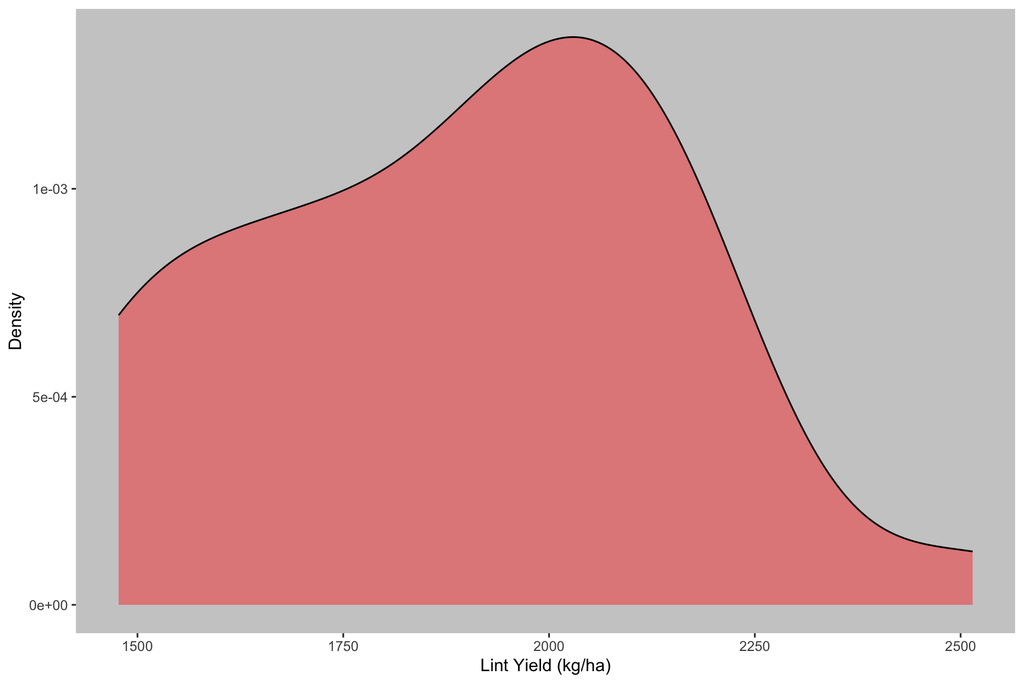

```r
lint_yield %>%
  ggplot()+
  geom_density(aes(x = lint_kgha), fill = "red", alpha = 0.4)+
  labs(x = "Lint Yield (kg/ha)",
       y = "Density")+
  my_theme
```

**Looking at the density plot above the lint yield is ranging from $1500 kg ha^{-1}$ to $2500 kg ha^{-1}$ which is normal in case of cotton so, we confirm no anomalies with the data.**

## 5.7 Statistical Model

### 5.7.1 Modelling

```r
# Changing to sum-to-zero contrast
options(contrasts = c("contr.sum", "contr.poly"))

model <- lmer(lint_kgha ~ treatment + (1|blocks), data = lint_yield)

summary(model)
```

```
Linear mixed model fit by REML ['lmerMod']
Formula: lint_kgha ~ treatment + (1 | blocks)
   Data: lint_yield

REML criterion at convergence: 301.1

Scaled residuals:
     Min       1Q   Median       3Q      Max
-2.16207 -0.35725  0.01138  0.38636  2.45393

Random effects:
 Groups   Name        Variance Std.Dev.
 blocks   (Intercept)     0      0.0
 Residual             51581    227.1
Number of obs: 28, groups:  blocks, 4

Fixed effects:
            Estimate Std. Error t value
(Intercept)  1891.63      42.92  44.073
treatment1   -389.32     105.13  -3.703
treatment2     76.54     105.13   0.728
treatment3    -15.74     105.13  -0.150
treatment4     57.22     105.13   0.544
treatment5    202.26     105.13   1.924
treatment6     65.64     105.13   0.624

Correlation of Fixed Effects:
           (Intr) trtmn1 trtmn2 trtmn3 trtmn4 trtmn5
treatment1  0.000
treatment2  0.000 -0.167
treatment3  0.000 -0.167 -0.167
treatment4  0.000 -0.167 -0.167 -0.167
treatment5  0.000 -0.167 -0.167 -0.167 -0.167
treatment6  0.000 -0.167 -0.167 -0.167 -0.167 -0.167
optimizer (nloptwrap) convergence code: 0 (OK)
boundary (singular) fit: see help('isSingular')
```

**A linear mixed effect model was ran for the data as the experimental design was randomized complete block design with treatments as fixed and blocks as random effects.**

### 5.7.2 Checking Anova

```r
options(scipen = 999) # changing scientific notations to decimals
anova <- Anova(model, type = 3) %>%
  broom::tidy() # making a dataframe of the anova
```

Table 4: Anova table

| Terms | Statistic | Df | p-value |
| --- | --- | --- | --- |
| (Intercept) | 1942.3981 | 1 | 0.0000 |
| treatment | 15.9886 | 6 | 0.0138 |

```r
rcbd_mix_resid <- augment(model) %>%
  mutate(.studresid=rstudent(model))
```

### 5.7.3 Checking the Model Assumptions

- Independence (no pattern)
- Variance homogeneity (homoscedasticity)
- Normality
- Outlier detection (< -3 or > 3)

#### 5.7.3.1 Random effects are iid ~ N(0,var_a)

```r
randeff_rep <- ranef(model)$blocks

randeff_rep
```

```
  (Intercept)
1           0
2           0
3           0
4           0
```

**For random effects with so few levels (i.e., 4 since that’s the number of blocks), the QQ plot is one of the only ways to check for assumptions on random effects.**

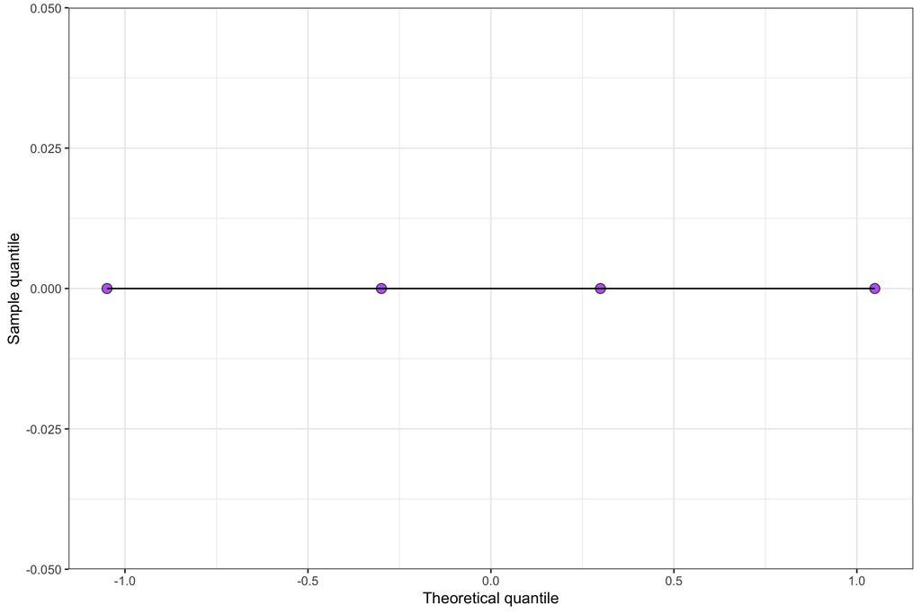

```r
ggplot(randeff_rep, aes(sample=`(Intercept)`))+
  stat_qq(  shape = 21,
            fill = "purple",
            size = 3,
            alpha = .7
  )+
  stat_qq_line()+
  labs(x = "Theoretical quantile",
       y = "Sample quantile")+
  theme_bw()
```

**Nothing to worry here, especially since we only have 4 points**.

#### 5.7.3.2 Independence, Homoscadecity and Outliers

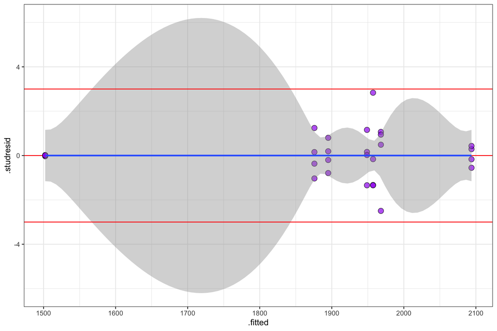

```r
ggplot(rcbd_mix_resid, aes(x=.fitted, y=.studresid))+
  geom_hline(yintercept = 0, color="red")+
  geom_point(shape = 21,
             fill = "purple",
             size = 3,
             alpha = .7)+
  geom_smooth()+
  geom_hline(yintercept = c(-3,3), color = "red")+
  theme_bw()
```

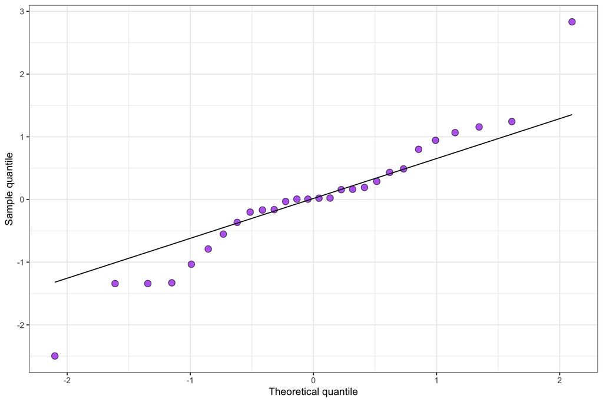

```r
ggplot(rcbd_mix_resid, aes(sample=.studresid))+
  stat_qq(  shape = 21,
            fill = "purple",
            size = 3,
            alpha = .7
  )+
  stat_qq_line()+
  labs(x = "Theoretical quantile",
       y = "Sample quantile")+
  theme_bw()
```

#### 5.7.3.3 Normality of Resiudals

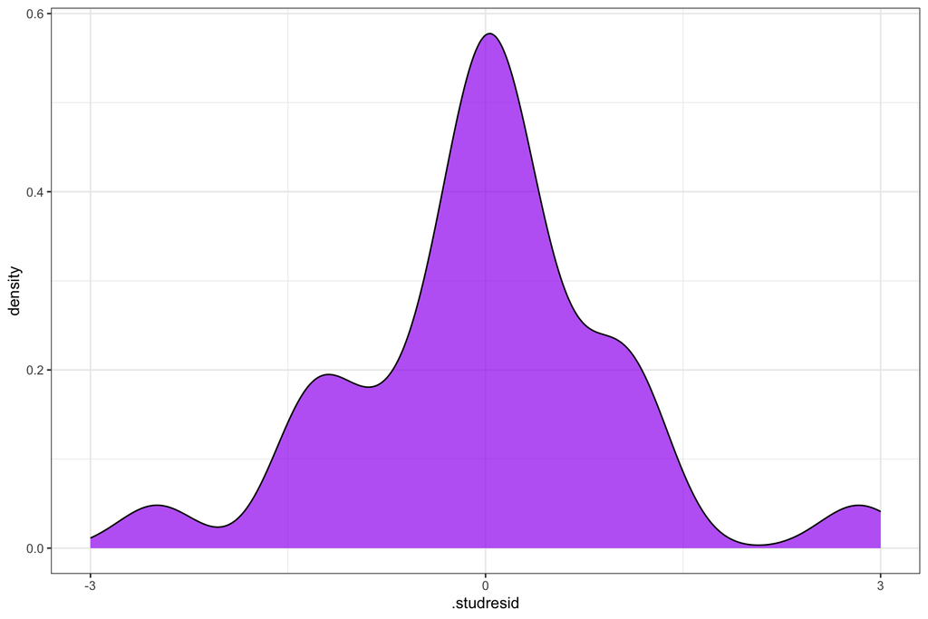

```r
ggplot(rcbd_mix_resid, aes(x=.studresid))+
  geom_density(color = "black",
               fill = "purple",
               alpha = .7)+
  scale_x_continuous(breaks = c(-3,0,3), limits = c(-3,3))+
  theme_bw()
```

- **Normality : The residual mean are gathered towards 0 and the distribution seems to be somewhat normal.**

### 5.7.4 Emmeans and Pairwise Comparison

```r
emmeans <- emmeans(model, ~treatment)

pwc <- cld(emmeans, adjust = "none",
           reversed = T, Letters = letters) %>%  # reversing the pwc so letter sequence goes from high to low.
  as.data.frame() %>%
  mutate(letters = trimws(.group))
```

Table 5: Pairwise comparison among the treatments where treatments sharing the same letters are statistically similar.

|  | Treatment | Emmean | SE | Df | Lower CL | Upper CL | Group | Letter |
| --- | --- | --- | --- | --- | --- | --- | --- | --- |
| 1 | 36+84 | 2093.884 | 113.5573 | 21 | 1857.729 | 2330.040 | a | a |
| 3 | 100+0 | 1968.166 | 113.5573 | 21 | 1732.011 | 2204.322 | a | a |
| 7 | 36+114 | 1957.268 | 113.5573 | 21 | 1721.113 | 2193.424 | a | a |
| 4 | 36+54 | 1948.849 | 113.5573 | 21 | 1712.694 | 2185.004 | a | a |
| 6 | 36+VRN | 1895.016 | 113.5573 | 21 | 1658.861 | 2131.172 | a | a |
| 2 | 36+24 | 1875.883 | 113.5573 | 21 | 1639.728 | 2112.039 | a | a |
| 5 | 0+0 | 1502.309 | 113.5573 | 21 | 1266.153 | 1738.464 | b | b |

**The treatments are significantly different from each other so pairwise comparison was performed to better understand which treatments were different among each other and which one was the best and worst among all. The treatments that share at least one same letter are statistically similar.**

### 5.7.5 Visualizing the Results

#### 5.7.5.1 Rates

*Objectives:*

**To compare the amount of sensor based recommended side-dress N rate with the fixed side-dress N rates.**

```r
mid_w_info_f <- info_mid %>%
  mutate(sd_lbac = as.numeric(sd_lbac),
  pp_kgha = as.integer(pp_lbac / 0.89), # converting preplant rate to kg/ha
  sd_kgha = as.integer(sd_lbac/ 0.89), # converting side dress rates to kg/ha
  trt = paste0(pp_kgha, "+", sd_kgha),
  total_kgha = pp_kgha + sd_kgha) %>%
  mutate(trt = case_when(
    plots == 106 ~ "40+VRN",
    plots == 203 ~ "40+VRN",
    plots == 301 ~ "40+VRN",
    plots == 407 ~ "40+VRN",
    T ~ trt))
```

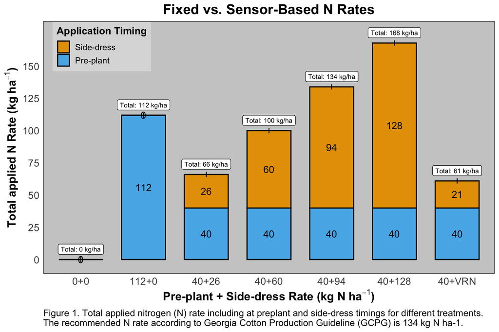

```r
vrn_only <- mid_w_info_f %>%
  mutate(trt = factor(trt,
                            levels = c("0+0",
                                       "112+0",
                                       "40+26",
                                       "40+60",
                                       "40+94",
                                       "40+128",
                                       "40+VRN"))) %>%
  mutate(total_vrn = ifelse(trt != "40+VRN", NA, total_kgha))


mid_w_info_f %>%
  mutate(trt = factor(trt,
                            levels = c("0+0",
                                       "112+0",
                                       "40+26",
                                       "40+60",
                                       "40+94",
                                       "40+128",
                                       "40+VRN"))) %>%
  mutate(total_vrn = ifelse(trt != "40+VRN", NA, total_kgha)) %>%
  group_by(trt, pp_kgha) %>%
  summarise(total = as.integer(mean(total_kgha)),
            sd_kgha = as.integer(mean(sd_kgha))) %>%
  pivot_longer(cols = contains("kgha")) %>%
  mutate(name = factor(name, level = c("sd_kgha", "pp_kgha"))) %>%
  ggplot(aes(x = trt, y = value))+
  geom_col(aes(fill = name),
           width = 0.7,
           color = "black",
           linewidth = .7) +
  scale_fill_manual(values = c("#E69F00", "#56B4E9", "#F0E442", "#009E73"),
                    labels = c("Side-dress", "Pre-plant")) +
  geom_segment(aes(x = trt, xend = trt, y = total - 2, yend = total +2))+
  # theme_cleveland()+
  labs(x = expression(bold(paste("Pre-plant + Side-dress Rate (kg N"~ha^-1, ")"))),
       y = expression(bold(paste("Total applied N Rate (kg"~ha^-1, ")"))),
       fill = "Application Timing",
       title = "Fixed vs. Sensor-Based N Rates",
       caption = "Figure 1. Total applied nitrogen (N) rate including at preplant and side-dress timings for different treatments. \nThe recommended N rate according to Georgia Cotton Production Guideline (GCPG) is 134 kg N ha-1. ")+
  geom_label(aes(label = paste0("Total: ", total, " kg/ha"),
                 y = total + 8), size = 3, fill = "white")+
  theme(legend.position = c(0.92,0.93),
        axis.title = element_text(face = "bold", size = 12),
        axis.text = element_text(size = 8),
        legend.title = element_text(face = "bold"),
        legend.key.size = unit(1, "cm"),
        panel.background = element_rect(fill = "white"),
        axis.title.y = element_text())+
  geom_text(aes(label = value), position = position_stack(vjust = 0.5), size = 4.5)+
  scale_y_continuous(breaks = seq(0,150, 25))+
  theme_minimal() +
  theme(
    legend.position = c(0.13, 0.9),
    legend.title = element_text(size = 13, face = "bold"),
    legend.text = element_text(size = 11),
    axis.text = element_text(size = 13),
    axis.title = element_text(size = 15, face = "bold"),
    plot.title = element_text(size = 18, face = "bold"),
    plot.caption = element_text(hjust = 0, size = 12),
    legend.background = element_rect(fill = "gray86", color = NA)
  )+
  theme(plot.title = element_text(hjust = 0.5, size = 18),
        panel.background = element_rect(fill = "gray80"),
        panel.grid = element_blank())
```

#### 5.7.5.2 N rate vs lint yield

*Objectives:*

**To contrast the effect of different side-dress fixed N rates and a sensor-based variable N rate on cotton lint yield.**

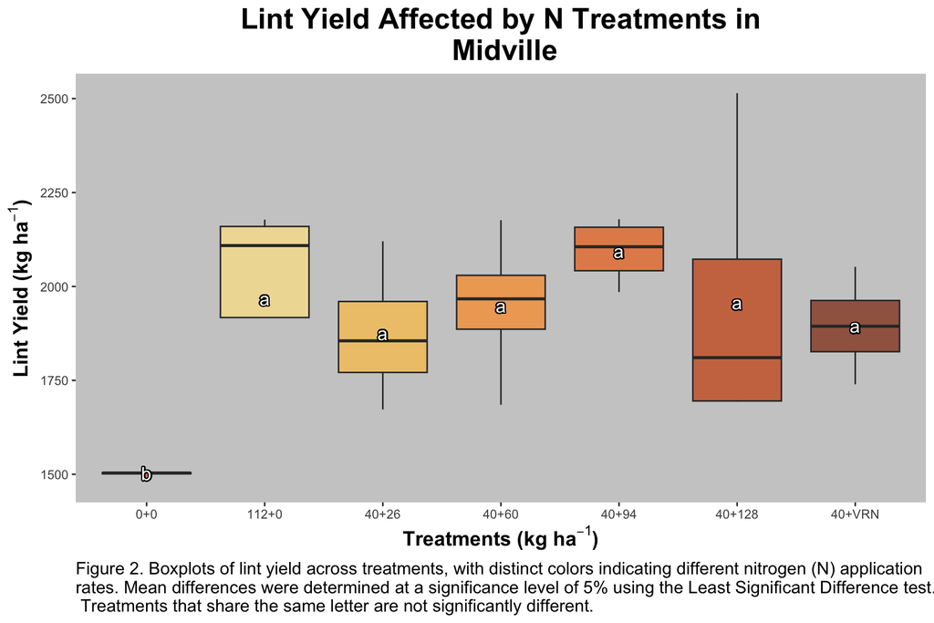

```r
lint_yield %>%
  ggplot()+
  geom_boxplot(aes(x = treatment, y = lint_kgha, fill = treatment), outlier.shape = NA, alpha = 0.7)+
  geom_point(data = pwc, aes(x = treatment, y = emmean, color = treatment))+
  geom_shadowtext(data = pwc, aes(x = treatment, y = emmean , label = letters),show.legend = F, bg = "black",  color = "white", size = 4.5)+
  labs(x = expression(bold(paste("Treatments (kg ha"^-1, ")"))),
       y = expression(bold(paste("Lint Yield (kg ha"^-1, ")"))),
       fill = "Treatments",
       title = "Lint Yield Affected by N Treatments in\n Midville",
       caption = "Figure 2. Boxplots of lint yield across treatments, with distinct colors indicating different nitrogen (N) application \nrates. Mean differences were determined at a significance level of 5% using the Least Significant Difference test.\n Treatments that share the same letter are not significantly different.")+
  theme_gray()+
  scale_x_discrete(labels = c("0+0",
                              "112+0",
                              "40+26",
                              "40+60",
                              "40+94",
                              "40+128",
                              "40+VRN"))+
  scale_fill_brewer(type = "seq", palette = "YlOrBr")+
  scale_y_continuous(breaks = seq(500, 3000, 250))+
  guides(color = F, fill = F)+
  theme(panel.background = element_rect(fill = "gray80"),
        panel.grid = element_blank(),
        legend.position = c(0.075, 0.82),
        legend.background = element_rect(fill = "gray88"),
        legend.key.height = unit(5.5, "mm"),
        axis.title = element_text(size = 14),
        plot.title = element_text(size = 20, face = "bold", hjust = 0.5),
        plot.caption = element_text(hjust = 0, size = 12))
```

## 5.8 Interpretation of Result

**Treatment rates, applied both at planting and at side-dress, are shown on Figure 1. Fixed side-dress rates ranged from 0 to 128 kg N ha-1. Sensor-based VRN was 21kg N ha-1 at side dressing when averaged across all VRN plots and ranged from 0 to 37 kg N ha-1 on a plot basis. The recommended side-dress application rate of 21 kg N ha-1 from sensor-based N treatment was 78% less than the conventional recommended rate of 134 (40 + 94) kg N ha-1(Figure 1).**

# 6 Team work in GitHub

Whether you are working with your future-self or as duos, make sure to stage, commit, and push after finishing each of the sub-sections above. When committing, write commit messages that are short and descriptive (e.g., finished wrangling).

If you are working in duos, make sure to split the workload. I will check your collaborative work through the commit history, and if one student has contributed significantly more than the other, than that will impact grades.

**Tip 1**: to avoid merge conflicts, make sure to **pull** first, and then start working locally. That will ensure that any changes made by your partner will be “downloaded” before you make changes to the files locally.

**Tip 2**: make use of the Issues on this repository to set up to-do lists and assign tasks to different people. You can also use each issue/task to discuss how things should be run and get to an agreement.

# 7 Submitting your work

Once you have developed all the code and answers, make sure to Render this quarto file.

**Notes on rendering**:

- Make sure to render your work and inspect how the final html look like.
- If it does not look professional for whatever reason, then fix the issue, re-render it, recheck.
- Only send me your work once your html file looks professional.
- Some potential issues you may encounter and how to fix them:
  - Some times your code may be creating a table output that is way to long and cumbersome to scroll through when rendered. If this is the case, make it more professional looking by using the `head()` function to only print the first handful of rows (instead of thousands of rows).
  - **DO NOT** delete the file’s heading levels (# and ##). They set up the proper heading 1 and 2 levels, and I use them to guide my grading.
  - If a given chunk is also outputting warnings or messages, inhibit this behavior by changing the chunk options `message` and `warning` to `FALSE`.
  - If, after rendered, 2 lines of text are connected and you wish to “break line” between them, add 2 extra spaces after the first one.

After rendering, an .html file will be created on your `code` folder.

Rename this file to `LASTNAME1-LASTNAME2_midtermproject.html`.  
For ex., `Bastos-Mendes_midtermproject.html`.

Send the html file to my email (lmbastos@uga.edu) by **April 11th** 11:59 pm.